# Research Report 2: oral presentation guidelines

Presenting one data decision

This presentation represents 25% of the grade for Research Report 2.

# What changes from RR1

For RR1, the oral presentation was about **data visualization**: you had to present one plot, and explain it clearly.

For RR2, the oral presentation is about **data decision**. Real data is never clean. At some point in every analysis, you run into a difficulty: missing values, strange outliers, a variable that is very skewed, hesitation about how to build your models… And each time, you have to make a decision. These decisions are rarely discussed in research papers, but they can completely change the results.

So in this presentation, you will present **one difficulty you found in your data, and how you handled it**. The goal is to show that you can spot a problem, understand why it matters, consider different solutions, and justify the one you chose.

The format is the same as for RR1: 5 minutes maximum, one slide.

# Which kind of difficulty?

Here are typical difficulties you may have met in your RR2. Pick **one**.

- **Missing values:** Some observations have no value for a variable you need. The question is not only “how many?”, but “who?”: if the missing values are concentrated in one group, simply deleting them can bias your results.
- **Outliers:** A few observations are extremely far from the others. They might be errors, or real but unusual cases. Should you keep them, remove them, or check whether your results depend on them?
- **Non-independent observations:** Your observations are grouped: several answers from the same person, students from the same school, respondents from the same country. Observations from the same group tend to be similar, which violates the independence assumption of most models we’ve seen.
- **A very skewed variable:** One of your variables has most of its values on one side, and a long tail on the other (like income, or the number of hours spent on something). Should you use it as it is, binarize it, or transform it?
- **Several possible models:** You could test your question in different ways (with or without some control variables, with a linear or a logistic regression…), and you didn’t know which one to choose. How did you decide, and do your conclusions change from one model to another?
- **Filtering the sample:** Should you use the whole sample, or focus on a sub-group (only young people, only one region, only one country)? Each choice answers a slightly different question.
- **Building a variable:** To measure a concept, should you use one single question, or combine several questions into an index? Where should you put the threshold when you cut a continuous variable into categories?
- **Something else:** For instance: impossible values or coding errors (like the 217 in TD 3), a variable stuck at a maximum or a minimum (many people with the highest possible score), or categories with too few observations to say anything.

The best topic is a problem you actually met in your RR2, not one you invented for the presentation. “I renamed my variables” is not a data decision: there is no difficulty, and no choice to make.

# Grading

## Formatting (2 pts)

- The presentation consists of a **single slide**
- The slide should look nice: a colored plot, clear axis names, text large enough to be read from the back of the room.
- The presentation lasts a **maximum of 5 minutes**. You are strongly encouraged to aim for less. You won’t be sanctioned for finishing early, but you will be penalized if you go even 5 seconds over 5 minutes. Mastering your time is important.

## Clarity of presentation (3 pts)

- **You speak clearly to the audience:**
  - you don’t read your notes;
  - you look at the audience, not at the professor;
  - you speak in a way that will be easily understood by your audience. You may speak in English or French.
- **You present the plot clearly**, as for RR1: what is on the axes (with units), what each mark represents (a dot, a bar…), and how to read the type of plot. Keep this part short: the plot is here to support your decision, not the other way around.
- **You present your decision clearly.** I recommend that you follow this order (the order itself is optional, but each component must be present):
  1. **The context.** In two or three sentences: your research question, and the data you use.
  2. **The difficulty.** What is the problem, and how did you find it?
  3. **Why it matters.** What would go wrong if you ignored it? Be concrete: which result would be biased, or misleading, and why?
  4. **The options.** What could you have done? Present at least two possible solutions.
  5. **Your decision.** Which option did you choose, and why this one rather than the others?
  6. **The consequences.** What did your decision change in your results? If you can, compare the results with and without your decision (and if you can’t, explain why).

IMPORTANT: only focus on one data analysis decision, even if you have several ones.

# Example

Suppose you worked on the dataset of university students and generative AI (`ai_students.csv`), and your research question was: **Is the use of generative AI associated with lower grades?**

Here is a plot you could show:

Here is roughly what a good presentation of this decision would sound like:

[On the slide, this plot:

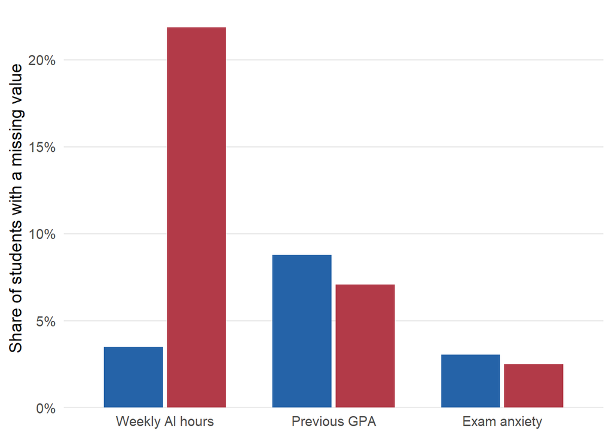

```r
library(tidyverse)
data = read_csv("../Week 11/ai_students.csv")

# Share of students with a missing value, for three variables, in each type of university
missing_by_policy = data %>%
  group_by(Institutional_Policy) %>%
  summarise(`Weekly AI hours` = mean(is.na(Weekly_GenAI_Hours)) * 100,
            `Previous GPA`    = mean(is.na(Pre_Semester_GPA)) * 100,
            `Exam anxiety`    = mean(is.na(Anxiety_Level_During_Exams)) * 100) %>%
  pivot_longer(cols = -Institutional_Policy,
               names_to = "variable", values_to = "pct_missing") %>%
  mutate(variable = factor(variable,
                           levels = c("Weekly AI hours", "Previous GPA", "Exam anxiety")))

ggplot(missing_by_policy,
       aes(x = variable, y = pct_missing, fill = Institutional_Policy)) +
  geom_col(position = position_dodge(width = 0.75), width = 0.7) +
  scale_fill_manual(values = c("Allowed" = "#2563A8", "Banned" = "#B23A48")) +
  scale_y_continuous(labels = function(x) paste0(x, "%"),
                     expand = expansion(mult = c(0, 0.05))) +
  labs(x = NULL, y = "Share of students with a missing value") +
  theme_minimal(base_size = 14) +
  theme(legend.position = "none",
        panel.grid.major.x = element_blank(),
        panel.grid.minor = element_blank())
```

> [Orally:]

> “My research question was whether students who use generative AI more get lower grades. I used a dataset of 5,000 university students, with their number of hours of AI use per week, their GPA at the end of the semester, and the policy of their university on AI: some universities allow it, others ban it.

> Before running my regression, I checked for missing values. Around 7%, had no value for their weekly hours of AI use. I decided to check how these missing values were distributed.

> That’s what this plot shows. On the x-axis, there are three variables of my dataset: weekly AI hours, previous GPA, and exam anxiety. On the y-axis, the share of students who have a missing value on each variable. Each bar represents one type of university: in blue, universities that allow AI, and in red, universities that ban it.

> For previous GPA and exam anxiety, the bars are about the same height: missing values are equally frequent in both types of university. But for AI hours, it’s completely different: about 3.5% of missing values where AI is allowed, against 22% where it’s banned. So the problem is not that banned universities collected worse data overall. It’s specifically the question about AI use that students didn’t answer. Thus, it’s likely that when AI is forbidden, some students don’t want to admit how much they use it.

> This matters a lot because by default, R simply deletes students with a missing value from the regression. So I would lose more than 20% of the students from universities that ban AI, and very likely the heaviest users, the ones with the most to hide.

> Fortunately, it did not change my conclusions. With all students together, I found no significant relationship between AI use and grades. And I found the same thing looking only at students in universities where AI is allowed.